# Lecture 15 Drawing Causal Diagrams

Nick Huntington-Klein

February 27, 2019

## Recap

- Last time we covered the concept of “controlling” or “adjusting” for a variable
- And we knew what to control for because of our causal diagram
- A causal diagram is your *model* of what you think the data-generating process is
- Which you can use to figure out how to *identify* particular arrows of interest

## Today

- Today we’re going to be working through the process of how to *make* causal diagrams
- This will require us to *understand* what is going on in the real world
- (especially since we won’t know the right answer, like when we simulate our own data!)
- And then represent our understanding in the diagram

## Remember

- Our goal is to *represent the underlying data-generating process*
- This is going to require some common-sense thinking
- As well as some economic intuition
- In real life, we’re not going to know what the right answer is
- Our models will be wrong. We just need them to be useful

## Steps to a Causal Diagram

1. Consider all the variables that are likely to be important in the data generating process (this includes variables you can’t observe)
2. For simplicity, combine them together or prune the ones least likely to be important
3. Consider which variables are likely to affect which other variables and draw arrows from one to the other
4. (Bonus: Test some implications of the model to see if you have the right one)

## Some notes

- Drawing an arrow requires a *direction*. You’re making a statement!
- Omitting an arrow is a statement too - you’re saying neither causes the other (directly)
- If two variables are correlated but neither causes the other, that means they’re both caused by some other (perhaps unobserved) variable that causes both - add it!
- There shouldn’t be any *cycles* - You shouldn’t be able to follow the arrows in one direction and end up where you started
  - If there *should* be a feedback loop, like “rich get richer”, distinguish between the same variable at different points in time to avoid it

## So let’s do it!

- Let’s start with an econometrics classic: what is the causal effect of an additional year of education on earnings?
- That is, if we reached in and made someone get one more year of education than they already did, how much more money would they earn?

## 1. Listing Variables

- We can start with our two main variables of interest:
  - Education [we call this the “treatment” or “exposure” variable]
  - Earnings [the “outcome”]

## 1. Listing Variables

- Then, we can add other variables likely to be relevant
- Focus on variables that are likely to cause or be caused by treatment
- ESPECIALLY if they’re related both to the treatment and the outcome
- They don’t have to be things you can actually observe/measure
- Variables that affect the outcome but aren’t related to anything else aren’t really important (you’ll see why next week)

## 1. Listing Variables

- So what can we think of?
  - Ability
  - Socioeconomic status
  - Demographics
  - Phys. ed requirements
  - Year of birth
  - Location
  - Compulsory schooling laws
  - Job connections

## 3. Arrows!

- Consider which variables are likely to cause which others
- And, importantly, *which arrows you can leave out*
- The arrows you *leave out* are important to think about - you sure there’s no effect? - and prized! You need those NON-arrows to be able to causally identify anything.

## 3. Arrows

- Let’s start with our effect of interest
- Education causes earnings

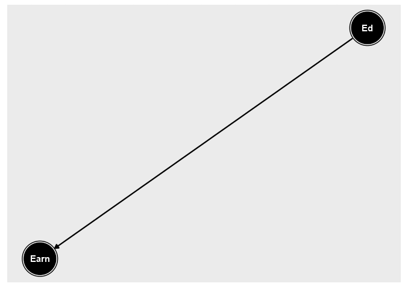

## 3. Arrows

- Remaining: Background, Year of birth, Location, Compulsory schooling, and Job Connections
- All of these but Job Connections should cause Ed

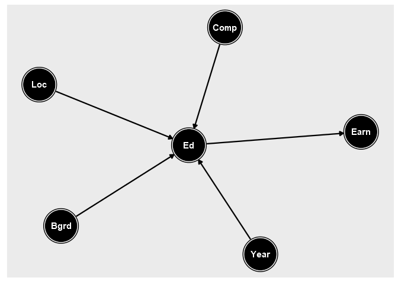

## 3. Arrows

- Seems like Year of Birth, Location, and Background should ALSO affect earnings. Job Connections, too.

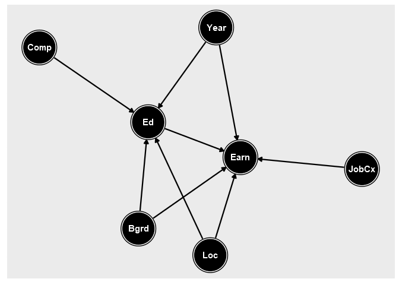

## 3. Arrows

- Job connections, in fact, seems like it should be caused by Education

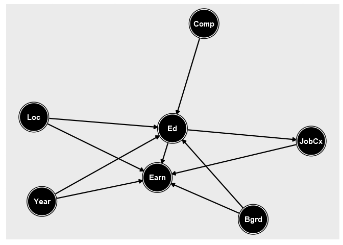

## 3. Arrows

- Location and Background are likely to be related, but neither really causes the other. Make unobservable U1 and have it cause both!

## Causal Diagrams

- The nice thing about these diagrams is that we can test (some of) our assumptions!
- We can’t test assumptions about which direction the arrows go, but notice that the diagram implies that certain relationships WON’T be there!
- For example, in our diagram, all relationships between `Comp` and `JobCx` go through `Ed`
- So if we control for `Ed`, `cor(Comp,JobCx)` should be zero - we can test that! We’ll do more of this later.

## Dagitty.net

- These graphs can be drawn by hand
- Or we can use a computer to help
- We will be using dagitty.net to draw these graphs
- (You can also draw them with R code - see the slides, but you won’t need to know this)

## Dagitty.net

- Go to dagitty.net and click on “Launch”
- You will see an example of a causal diagram with nodes (variables) and arrows
- Plus handy color-coding and symbols. Green triangle for exposure/treatment, and blue bar for outcome.
- The green arrow is the “causal path” we’d like to *identify*

## Dagitty.net

- Go to Model and New Model
- Let’s recreate our Education and Earnings diagram
- Put in Education as the exposure and Earnings as the outcome (you can use longer variable names than we’ve used here)

## Dagitty.net

- Double-click on blank space to add new variables.
- Add all the variables we’re interested in.

## Dagitty.net

- Then, double click on some variable `X`, then once on another variable `Y` to get an arrow for `X -> Y`
- Fill in all our arrows!

## Dagitty.net

- Feel free to move the variables around with drag-and-drop to make it look a bit nicer
- You can even drag the arrows to make them curvy

## Dagitty.net

- Next, we can classify some of our variables.
- Hover over `U1` and tap the ‘u’ key to make Dagitty register it as unobservable

## Dagitty.net

- Now, look at all that red!
- Dagitty uses red to show you that a variable is going to cause problems for us! Like `tech` did last lecture
- We can tell Dagitty that we plan to adjust/control for these variables in our analysis by hovering over them and hitting the ‘a’ key
- When there’s no red, we’ve identified the green arrow we’re interested in!

## Dagitty.net

- Notice that all Dagitty knows is what we told it about our model
- And that was enough for it to tell us what we needed to adjust for to identify our effect!
- That’s not super complex computer magic, it’s actually a fairly simple set of rules, which we’ll go over next time.

## Practice

- Consider the causal question “does a longer night’s sleep extend your lifespan?”
1. List variables [think especially hard about what things might lead you to get a longer night’s sleep]
2. Simplify
3. Arrows
- Then, when you’re done, draw it in Dagitty.net!